# 자동차 보험료 계산

yeonjeong

#### 사고건수와 사고심도에 대한 모델링을 통해 자동차 보험료를 예측할 수 있다.

- 자동차 사고건수 ~ Poisson glm, NB glm, zip 등
- 자동차 사고심도 ~ Gamma glm

#### 자동차 보험자료의 각 변수들(factor)

- Kilometers: 자동차 년간 주행거리 1~5
- Zone: 1~7
- Bonus: 1~7
- Make: 1~9
- Insured: 보험가입자수
- Claims: 총 사고건수
- Payment: 총보험금 지불액

```r
library(ggplot2); library(dplyr)
library(pscl) # zip modelling을 위함
car<-read.table("C:\\Users\\SAMSUNG\\Desktop\\Car.csv", sep=",", header=T)
head(car)
```

```
##   Kilometres Zone Bonus Make Insured Claims Payment
## 1          1    1     1    1     455    108  392491
## 2          1    1     1    2      69     19   46221
## 3          1    1     1    3      73     13   15694
## 4          1    1     1    4    1292    124  422201
## 5          1    1     1    5     191     40  119373
## 6          1    1     1    6     478     57  170913
```

```r
colnames(car)<-c("K","Z","B","M","m","n","y") # m; 가입자수 n; claim, y:payment
```

### 1) 자동차 사고건수N~pois(lamda*m) 이때 lamda=n/m 에 대한 GLM

```r
car2<-car[car$m!=0,] # 보험가입자 수 가 0인 데이터 삭제

# 교호작용 없는 모델
lm1<-glm(n~factor(K)+factor(Z)+factor(B)+factor(M), family=poisson(link=log), data=car2, offset=log(m)) # log(n/m) 에대한 modeling
summary(lm1)$aic
```

```
## [1] 10653.42
```

```r
# 교호작용 있는 모델
#lm2<-glm(n ~ factor(K) + factor(Z) + factor(B) + factor(M) +  factor(K):factor(Z) + factor(K):factor(B) + factor(Z):factor(B) +factor(K):factor(M) + factor(Z):factor(M) + factor(B):factor(M) + factor(K):factor(Z):factor(B) + factor(K):factor(Z):factor(M) + factor(B):factor(Z):factor(M), family=poisson(link=log), data=car2, offset=log(m)) # log(n/m) 에대한 modeling
#step(lm2)

#최종모델
pois_final <- glm(formula = n ~ factor(K) + factor(Z) + factor(B) + factor(M) +
                    factor(K):factor(Z) + factor(K):factor(B) + factor(Z):factor(B) +
                    factor(K):factor(M) + factor(Z):factor(M) + factor(B):factor(M), family = poisson(link = log), data = car2, offset = log(m))

summary(pois_final)$aic
```

```
## [1] 10243.59
```

### ZIP(Zero Inflated Poisson)

#### 0이많은 포아송 모델에 대한 분석

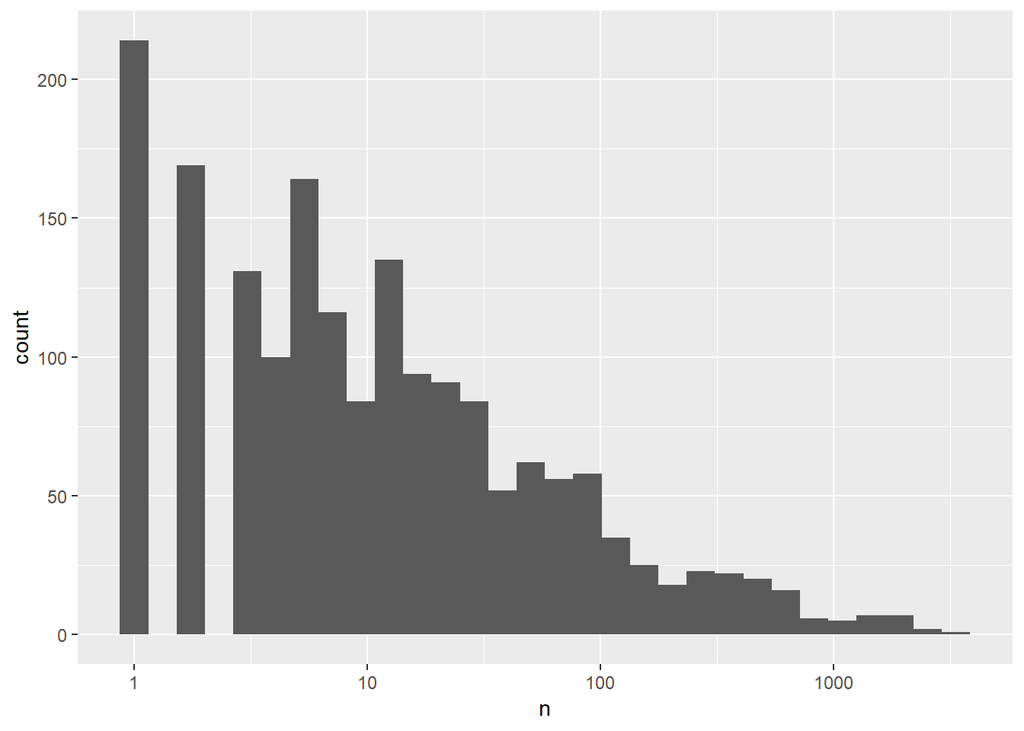

```r
ggplot(car, aes(n))+geom_histogram() + scale_x_log10()
```

```r
zip1<-zeroinfl(n~factor(K)+factor(Z)+factor(B)+factor(M), data=car2, offset=log(m))
summary(zip1)
```

```
##
## Call:
## zeroinfl(formula = n ~ factor(K) + factor(Z) + factor(B) + factor(M),
##     data = car2, offset = log(m))
##
## Pearson residuals:
##     Min      1Q  Median      3Q     Max
## -6.5129 -0.7262 -0.1474  0.6368  9.7192
##
## Count model coefficients (poisson with log link):
##              Estimate Std. Error  z value Pr(>|z|)
## (Intercept) -1.813528   0.013759 -131.805  < 2e-16 ***
## factor(K)2   0.212662   0.007525   28.263  < 2e-16 ***
## factor(K)3   0.320263   0.008662   36.975  < 2e-16 ***
## factor(K)4   0.406887   0.012068   33.716  < 2e-16 ***
## factor(K)5   0.576866   0.012837   44.938  < 2e-16 ***
## factor(Z)2  -0.238113   0.009496  -25.076  < 2e-16 ***
## factor(Z)3  -0.385824   0.009672  -39.891  < 2e-16 ***
## factor(Z)4  -0.581928   0.008654  -67.246  < 2e-16 ***
## factor(Z)5  -0.323889   0.014534  -22.285  < 2e-16 ***
## factor(Z)6  -0.525576   0.011889  -44.205  < 2e-16 ***
## factor(Z)7  -0.730501   0.040699  -17.949  < 2e-16 ***
## factor(B)2  -0.479093   0.012094  -39.615  < 2e-16 ***
## factor(B)3  -0.693311   0.013508  -51.325  < 2e-16 ***
## factor(B)4  -0.825946   0.014635  -56.438  < 2e-16 ***
## factor(B)5  -0.922946   0.013974  -66.049  < 2e-16 ***
## factor(B)6  -0.993648   0.011630  -85.441  < 2e-16 ***
## factor(B)7  -1.327624   0.008685 -152.858  < 2e-16 ***
## factor(M)2   0.079029   0.021298    3.711 0.000207 ***
## factor(M)3  -0.247305   0.025094   -9.855  < 2e-16 ***
## factor(M)4  -0.649522   0.024218  -26.820  < 2e-16 ***
## factor(M)5   0.156332   0.020238    7.725 1.12e-14 ***
## factor(M)6  -0.334790   0.017400  -19.241  < 2e-16 ***
## factor(M)7  -0.055109   0.023346   -2.360 0.018251 *
## factor(M)8  -0.037672   0.031650   -1.190 0.233938
## factor(M)9  -0.068031   0.009956   -6.833 8.30e-12 ***
##
## Zero-inflation model coefficients (binomial with logit link):
##             Estimate Std. Error z value Pr(>|z|)
## (Intercept)  -91.996    142.788  -0.644   0.5194
```

[output cut: 14 more lines]

```
## factor(B)6    11.501     37.578   0.306   0.7596
## factor(B)7   -14.418         NA      NA       NA
## factor(M)2    11.509     93.631   0.123   0.9022
## factor(M)3    -5.723   1704.519  -0.003   0.9973
## factor(M)4    32.426     99.342   0.326   0.7441
## factor(M)5    11.893     93.638   0.127   0.8989
## factor(M)6    11.043     93.635   0.118   0.9061
## factor(M)7    10.867     93.641   0.116   0.9076
## factor(M)8    12.856     93.639   0.137   0.8908
## factor(M)9    -5.405   1399.800  -0.004   0.9969
## ---
## Signif. codes:  0 '***' 0.001 '**' 0.01 '*' 0.05 '.' 0.1 ' ' 1
##
## Number of iterations in BFGS optimization: 195
## Log-likelihood: -5284 on 50 Df
```

```r
-5284*(-2)+2*25 #zip1의 aic
```

```
## [1] 10618
```

### 2) 자동차사고건수N~binom(m, p)

```r
car2[car2$n/car2$m>1,] #n/m 값이 1보다 크므로 빼고 하자
```

```
##      K Z B M m n     y
## 1292 3 7 4 7 2 3 11762
```

```r
car3<-car2[car2$n/car2$m<1,]

# 교호작용 없는모델
binom1<-glm(cbind(n, m-n)~factor(K)+factor(Z)+factor(B)+factor(M), data=car3, family=binomial(link=logit))
summary(binom1)
```

```
##
## Call:
## glm(formula = cbind(n, m - n) ~ factor(K) + factor(Z) + factor(B) +
##     factor(M), family = binomial(link = logit), data = car3)
##
## Deviance Residuals:
##     Min       1Q   Median       3Q      Max
## -7.9945  -0.8850  -0.1746   0.6308   6.5771
##
## Coefficients:
##              Estimate Std. Error  z value Pr(>|z|)
## (Intercept) -1.651511   0.014419 -114.537  < 2e-16 ***
## factor(K)2   0.227103   0.007770   29.228  < 2e-16 ***
## factor(K)3   0.341422   0.008946   38.163  < 2e-16 ***
## factor(K)4   0.431241   0.012458   34.617  < 2e-16 ***
## factor(K)5   0.616699   0.013351   46.191  < 2e-16 ***
## factor(Z)2  -0.259760   0.009896  -26.248  < 2e-16 ***
## factor(Z)3  -0.418076   0.010045  -41.621  < 2e-16 ***
## factor(Z)4  -0.624531   0.008983  -69.524  < 2e-16 ***
## factor(Z)5  -0.353918   0.015052  -23.513  < 2e-16 ***
## factor(Z)6  -0.566413   0.012274  -46.149  < 2e-16 ***
## factor(Z)7  -0.790080   0.041799  -18.902  < 2e-16 ***
## factor(B)2  -0.533596   0.012751  -41.847  < 2e-16 ***
## factor(B)3  -0.765096   0.014142  -54.101  < 2e-16 ***
## factor(B)4  -0.909362   0.015210  -59.786  < 2e-16 ***
## factor(B)5  -1.013454   0.014555  -69.629  < 2e-16 ***
## factor(B)6  -1.085352   0.012172  -89.168  < 2e-16 ***
## factor(B)7  -1.434065   0.009190 -156.051  < 2e-16 ***
## factor(M)2   0.081760   0.021985    3.719   0.0002 ***
## factor(M)3  -0.261791   0.025753  -10.165  < 2e-16 ***
## factor(M)4  -0.696076   0.024782  -28.088  < 2e-16 ***
## factor(M)5   0.166767   0.021013    7.937 2.08e-15 ***
## factor(M)6  -0.356286   0.017855  -19.954  < 2e-16 ***
## factor(M)7  -0.061415   0.024061   -2.553   0.0107 *
## factor(M)8  -0.047682   0.032524   -1.466   0.1426
## factor(M)9  -0.072380   0.010283   -7.039 1.94e-12 ***
## ---
## Signif. codes:  0 '***' 0.001 '**' 0.01 '*' 0.05 '.' 0.1 ' ' 1
##
## (Dispersion parameter for binomial family taken to be 1)
##
##     Null deviance: 36329  on 2152  degrees of freedom
## Residual deviance:  3232  on 2128  degrees of freedom
## AIC: 10755
##
## Number of Fisher Scoring iterations: 4
```

```r
# 교호작용 있는 모델
#binom2<-glm(cbind(n, m-n)~factor(K)*factor(B)*factor(M)*factor(Z), data=car3, family=binomial(link=logit))
#step(binom2)

# 최종모델
binom_final<-glm(cbind(n, m - n) ~ factor(K) + factor(B) + factor(M) +
                   factor(Z) + factor(K):factor(B) + factor(K):factor(M) + factor(B):factor(M) +
                   factor(K):factor(Z) + factor(B):factor(Z) + factor(M):factor(Z),
                 family = binomial(link = logit), data = car[car$n/car$m<1,])
summary(binom_final)$aic
```

```
## [1] 10209.25
```

### 위 두 모형들에 대한 Pearson 표준화 잔차 및 Deviance 잔차

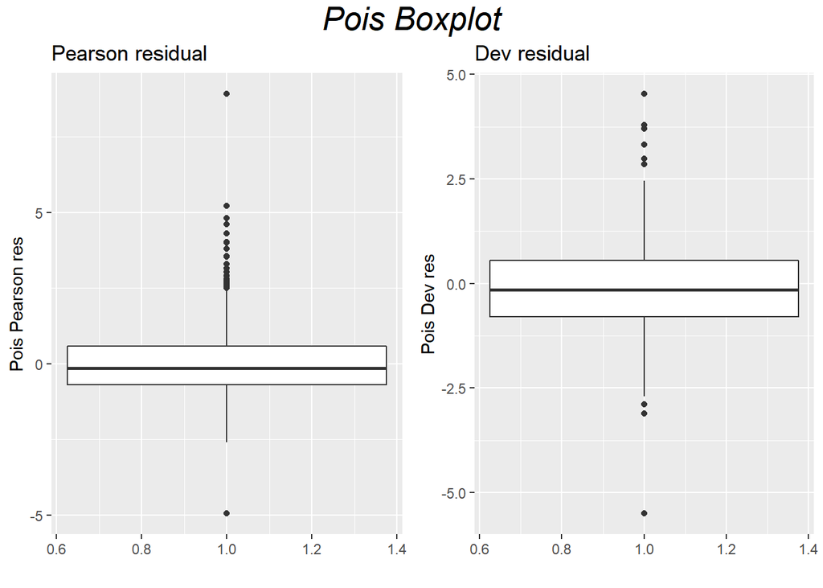

```r
car2<-car2 %>% mutate(pois_pearson = residuals(pois_final, type="pearson"))
car2<-car2 %>% mutate(pois_dev = residuals(pois_final, type="deviance"))
car2<-car2 %>% mutate(F=qnorm(rank(pois_pearson )/(length(pois_pearson )+1)))
car2<-car2 %>% mutate(F2=qnorm(rank(pois_dev )/(length(pois_dev )+1)))


car3<-car3 %>% mutate(binom_pearson = residuals(binom_final, type="pearson"))
car3<-car3 %>% mutate(binom_dev = residuals(binom_final, type="deviance"))
car3<-car3 %>% mutate(F=qnorm(rank(binom_pearson )/(length(binom_pearson )+1)))
car3<-car3 %>% mutate(F2=qnorm(rank(binom_dev )/(length(binom_dev )+1)))


# 잔차들의 여러 plot - Poisson
library(grid); library(gridExtra); library(ggpmisc)
q1<-ggplot(car2, aes(x=1, y=pois_pearson)) + geom_boxplot() + labs(x=" ",y="Pois Pearson res") + ggtitle("Pearson residual ")
q2<-ggplot(car2, aes(x=1, y=pois_dev)) + geom_boxplot()  + labs(x=" ",y="Pois Dev res") + ggtitle("Dev residual ")
grid.arrange(q1,q2, ncol=2,
             top = textGrob("Pois Boxplot",gp=gpar(fontsize=20,font=3)))
```

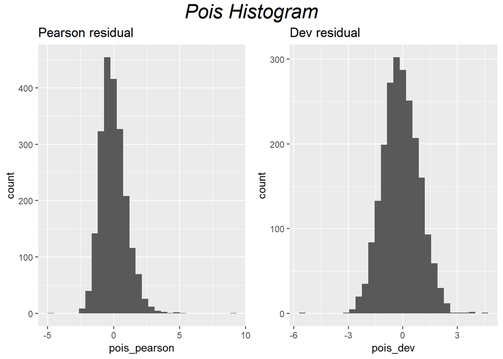

```r
q3<-ggplot(car2, aes(pois_pearson)) + geom_histogram() + ggtitle("Pearson residual ")
q4<-ggplot(car2, aes(pois_dev)) + geom_histogram() + ggtitle("Dev residual ")
grid.arrange(q3,q4, ncol=2,
             top = textGrob("Pois Histogram",gp=gpar(fontsize=20,font=3)))
```

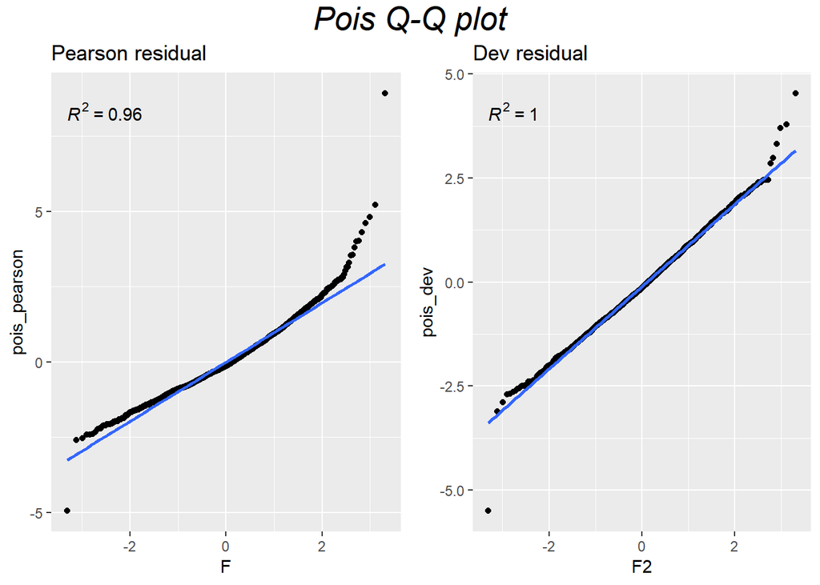

```r
q5<- ggplot(car2, aes(F,pois_pearson)) + geom_point() + geom_smooth(method="lm", se=F) + ggtitle("Pearson residual")+
  stat_poly_eq(formula = y ~ x, aes(label = paste(..rr.label.., sep = "~~~")), parse = TRUE)
q6<- ggplot(car2, aes(x=F2, y=pois_dev)) + geom_point() + geom_smooth(method="lm", se=F) + ggtitle("Dev residual") +
  stat_poly_eq(formula = y ~ x, aes(label = paste(..rr.label.., sep = "~~~")), parse = TRUE)
grid.arrange(q5,q6, ncol=2,
             top = textGrob("Pois Q-Q plot",gp=gpar(fontsize=20,font=3)))
```

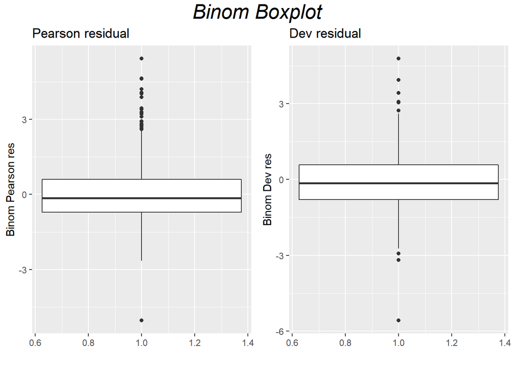

```r
# 잔차들의 여러 plot - Binom
p1<-ggplot(car3, aes(x=1, y=binom_pearson)) + geom_boxplot() + labs(x=" ",y="Binom Pearson res") + ggtitle("Pearson residual ")
p2<-ggplot(car3, aes(x=1, y=binom_dev)) + geom_boxplot()  + labs(x=" ",y="Binom Dev res") + ggtitle("Dev residual ")
grid.arrange(p1,p2, ncol=2,
             top = textGrob("Binom Boxplot",gp=gpar(fontsize=20,font=3)))
```

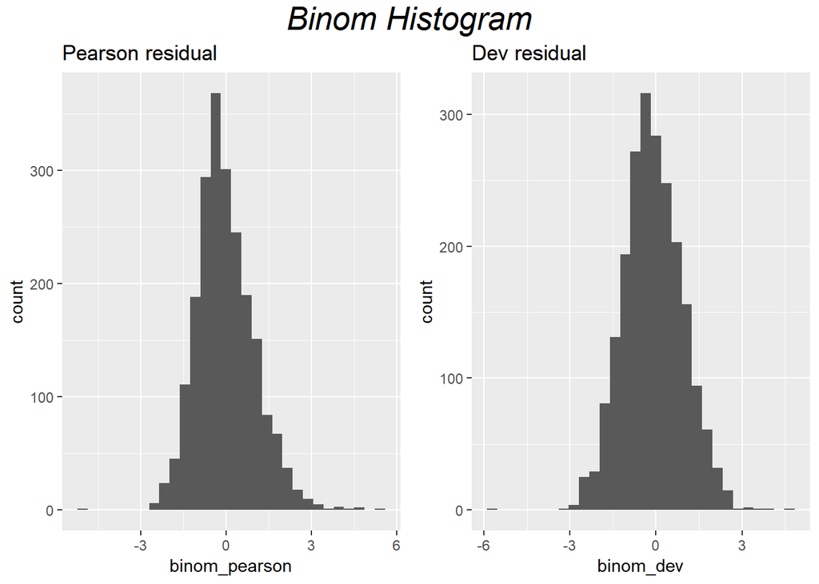

```r
p3<-ggplot(car3, aes(binom_pearson)) + geom_histogram() + ggtitle("Pearson residual ")
p4<-ggplot(car3, aes(binom_dev)) + geom_histogram() + ggtitle("Dev residual ")
grid.arrange(p3,p4, ncol=2,
             top = textGrob("Binom Histogram",gp=gpar(fontsize=20,font=3)))
```

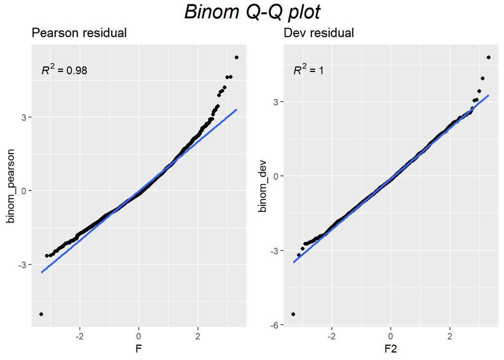

```r
p5<- ggplot(car3, aes(F,binom_pearson)) + geom_point() + geom_smooth(method="lm", se=F) + ggtitle("Pearson residual") +
  stat_poly_eq(formula = y ~ x, aes(label = paste(..rr.label.., sep = "~~~")), parse = TRUE)
p6<- ggplot(car3, aes(F2, binom_dev)) + geom_point() + geom_smooth(method="lm", se=F) + ggtitle("Dev residual") +
  stat_poly_eq(formula = y ~ x, aes(label = paste(..rr.label.., sep = "~~~")), parse = TRUE)
grid.arrange(p5,p6, ncol=2,
             top = textGrob("Binom Q-Q plot",gp=gpar(fontsize=20,font=3)))
```

#### 두 모델에 대한 비교 * n이 크고 p가 작으면 binomial이 poisson에 수렴한다. * 그러나 n에 비해 p가 크면 fitting이 불안정해 진다. * 단순추정값(n/m)은 설명변수의 조합을 고려하지 않은 전반적인 사고빈도 * 단순추정값과 다르게 glm모델링은 가입자가 없는 지역에 대하여도 예측이 가능하다.

### 3) 자동차 사고건수N~NB (overdispersion 문제를 해결)

```r
library(MASS)
X2<-sum(residuals(pois_final, type="pearson")^2)
X2/(dim(car2)[1]-dim(summary(pois_final)$coefficients)) # 일정 증가가 아니라 1.12배 정도 뻥튀기 되며 증가한다.
```

```
## [1] 1.123201 1.001647
```

```r
quasi1<-glm(formula = n ~ factor(K) + factor(Z) + factor(B) + factor(M) +
              factor(K):factor(Z) + factor(K):factor(B) + factor(Z):factor(B) +
              factor(K):factor(M) + factor(Z):factor(M) + factor(B):factor(M), family = quasipoisson, data = car2, offset = log(m))
summary(quasi1)
```

```
##
## Call:
## glm(formula = n ~ factor(K) + factor(Z) + factor(B) + factor(M) +
##     factor(K):factor(Z) + factor(K):factor(B) + factor(Z):factor(B) +
##     factor(K):factor(M) + factor(Z):factor(M) + factor(B):factor(M),
##     family = quasipoisson, data = car2, offset = log(m))
##
## Deviance Residuals:
##     Min       1Q   Median       3Q      Max
## -5.4972  -0.7873  -0.1445   0.5536   4.5329
##
## Coefficients:
##                         Estimate Std. Error t value Pr(>|t|)
## (Intercept)           -1.4875941  0.0421864 -35.262  < 2e-16 ***
## factor(K)2             0.1503022  0.0343482   4.376 1.27e-05 ***
## factor(K)3             0.0474810  0.0415929   1.142 0.253777
## factor(K)4            -0.0523865  0.0658107  -0.796 0.426120
## factor(K)5             0.1128495  0.0692598   1.629 0.103400
## factor(Z)2            -0.2554479  0.0417803  -6.114 1.17e-09 ***
## factor(Z)3            -0.4710139  0.0431327 -10.920  < 2e-16 ***
## factor(Z)4            -0.6763891  0.0382609 -17.678  < 2e-16 ***
## factor(Z)5            -0.4338354  0.0640864  -6.770 1.71e-11 ***
## factor(Z)6            -0.5726973  0.0512230 -11.180  < 2e-16 ***
## factor(Z)7            -0.8512292  0.1884318  -4.517 6.64e-06 ***
## factor(B)2            -0.5963095  0.0545363 -10.934  < 2e-16 ***
## factor(B)3            -0.8942245  0.0603411 -14.819  < 2e-16 ***
## factor(B)4            -1.0318505  0.0643900 -16.025  < 2e-16 ***
## factor(B)5            -1.1782842  0.0613564 -19.204  < 2e-16 ***
## factor(B)6            -1.2866528  0.0506067 -25.425  < 2e-16 ***
## factor(B)7            -1.6800966  0.0382122 -43.968  < 2e-16 ***
## factor(M)2            -0.1098945  0.0991940  -1.108 0.268055
## factor(M)3            -0.2706250  0.1198824  -2.257 0.024094 *
## factor(M)4            -0.8694302  0.0708650 -12.269  < 2e-16 ***
## factor(M)5             0.0673019  0.0767236   0.877 0.380488
## factor(M)6            -0.6360009  0.0677231  -9.391  < 2e-16 ***
## factor(M)7            -0.4970058  0.1050483  -4.731 2.39e-06 ***
## factor(M)8             0.1912271  0.1527682   1.252 0.210815
## factor(M)9            -0.3096961  0.0396164  -7.817 8.82e-15 ***
## factor(K)2:factor(Z)2  0.0263676  0.0251546   1.048 0.294669
## factor(K)3:factor(Z)2  0.0080136  0.0293243   0.273 0.784672
```

[output cut: 205 more lines]

```
## factor(B)3:factor(M)9  0.1179194  0.0504027   2.340 0.019409 *
## factor(B)4:factor(M)9  0.1405283  0.0530829   2.647 0.008179 **
## factor(B)5:factor(M)9  0.1986846  0.0503591   3.945 8.25e-05 ***
## factor(B)6:factor(M)9  0.2604586  0.0424128   6.141 9.94e-10 ***
## factor(B)7:factor(M)9  0.2658130  0.0326266   8.147 6.64e-16 ***
## ---
## Signif. codes:  0 '***' 0.001 '**' 0.01 '*' 0.05 '.' 0.1 ' ' 1
##
## (Dispersion parameter for quasipoisson family taken to be 1.123201)
##
##     Null deviance: 34070.1  on 2156  degrees of freedom
## Residual deviance:  2131.7  on 1920  degrees of freedom
## AIC: NA
##
## Number of Fisher Scoring iterations: 6
```

- quassi poisson 결과 1.12 의 overdispersion 값을 가짐을 알 수 있다.
- 이를 해결하기 위해 NB 모델을 적용해보았다.
- 그러나 모형이 복잡함에 비해 aic값에 큰 개선이 없어 pois모델을 택하기하였다.

```r
nb_final<- glm.nb(formula = n ~ factor(K) + factor(Z) + factor(B) + factor(M) +
                    factor(K):factor(Z) + factor(K):factor(B) + factor(Z):factor(B) +
                    factor(K):factor(M) + factor(Z):factor(M) + factor(B):factor(M) +
                    offset(log(m)), data = car[car$n/car$m < 1, ], init.theta = 5432.412386,
                  link = log)
summary(nb_final)$aic
```

```
## [1] 10208.4
```

### 4) 자동차사고심도에 대한 모델링

### 사고심도 y ~ Gamma

```r
car2<-car[car$y!=0,]
# 각 수준조합별로 반복수가 n인 그룹화 자료이므로 weight=n을 해야한다.
glm4<-glm(y/n~(factor(K)+factor(Z)+factor(B)+factor(M))^2, data=car2, family=Gamma(link="log"), weight=n)
#step(glm4) 결과 2차교호작용이 있는 모델이 최적 모델
gam_final<-glm(y/n ~ factor(K) + factor(Z) + factor(B) + factor(M) +
                 factor(K):factor(Z) + factor(K):factor(B) + factor(K):factor(M) +
                 factor(Z):factor(B) + factor(B):factor(M), family = Gamma(link = "log"),
               data = car2, weights = n)
summary(gam_final)$aic
```

```
## [1] 1863828
```

### 5) 자동차 보험료 계산

- 자동차 보험료 = 1인당 년간 평균 사고빈도 * 1건당 평균 사고심도

```r
# size <- predict.glm(pois_final, car, type = 'response')
# number <- predict.glm(gam_final, car, type = 'response')
# 보험료 = (number/m)*size
```